# Practice Activity Week 4

```r
library(tidyverse)
```

# Roundabouts

This week, our activity will explore how roundabouts are used around the world! You might not be as big of a fan of roundabouts as Dr. T, but these data allow us to investigate a fun and unique visualization technique—[a Sankey diagram](https://en.wikipedia.org/wiki/Sankey_diagram).

A Sankey diagram visualizes data **flows**. Specifically, the visual models the movement from one state to another. We are going to use a Sankey plot to visualize how traffic intersections are transformed into various types of roundabouts.

## The `roundabouts` Package

The [`roundabouts` R package](https://github.com/EmilHvitfeldt/roundabouts) provides a simple way to interact with the [Roundabouts Database](https://roundabouts.kittelson.com/). You likely do not have the package installed on your computer, so the first step is to install the package:

```r
pak::pak("emilhvitfeldt/roundabouts")
```

The `roundabouts` dataframe that is included in the package has an `address` variable which is a bit untidy. Below is some data cleaning code that will clean the `address` variable, and create three new variables: `town_city`, `county_area`, and `state_region`.

```r
library(roundabouts)

roundabouts_clean <- roundabouts |>
  mutate(
    # Step 1: Remove strange <![CDATA[ tags from the beginning of the address field
    address = stringr::str_remove(address, stringr::fixed("<![CDATA[")),
    # Step 2: Remove strang ]]> tags from the end of the address field
    address = stringr::str_remove(address, stringr::fixed("]]>")),
    # Step 3: Isolate the country at the end of the string between the ( ) symbols
    country = stringr::str_extract(address, "\\([^)]+\\)$"),
    # Step 4: Remove the brackets surrounding the country name
    country = stringr::str_remove_all(country, "[\\(\\)]"),
    # Step 5: Remove the country from the address field
    address2 = stringr::str_remove(address, "\\s*\\([^)]+\\)$")) |>
  # Step 6: Separate address into town, county, state by comma
  separate(address2,
                  into = c("town_city", "county_area", "state_region"),
                  sep = ",") |>
  # Step 7: Fix one instance of California instead of CA
  mutate(state_region = str_trim(state_region, side = "both"),
         state_region = fct_recode(state_region,
                                   "CA" = "California")
         ) |>
  # Step 8: Remove companies from states
  filter(! str_detect(state_region, pattern = "Co.")) |>
  # Step 9: Grab columns we will be using
  select(town_city, county_area, state_region, country,
         year_completed, type, previous_control_type, control_type)
```

## Creating a Region Variable

Alright, we now have the `country` of each roundabout, but that seems to fine grain for our analysis. If we’re interested in how roundabouts are used around the world, it seems like a `region` variable might be a better fit.

1. Create a new `continent` column in the dataset, which classifies each `country` into one of the five major continents—Americas, Europe, Asia, Oceania, Africa.

The `countrycode()` function from the `countrycode` package will be helpful here! Here is an example of how you can use this function to obtain the continent of a given country:

```r
countrycode::countrycode("Brazil",
            origin = "country.name",
            destination = "continent")
```

```r
roundabouts_clean <- roundabouts_clean |>
  mutate(continent = countrycode::countrycode(country,
                                              origin = "country.name",
                                              destination = "continent"))
```

## Exploring Roundabouts

Let’s explore the data a bit before we jump into visualizing these data.

2. What countries have the most roundabouts (in these data)? The fewest roundabouts?

```r
# determining the most roundabouts

roundabouts_clean |>
  group_by(country) |>
  summarise(count = n()) |>
  arrange(desc(count)) |>
  head(5)
```

```
# A tibble: 5 × 2
  country        count
  <chr>          <int>
1 United States  12907
2 Australia       3369
3 United Kingdom  1777
4 Canada          1245
5 New Zealand      860
```

```r
# determining the least roundabouts

roundabouts_clean |>
  group_by(country) |>
  summarise(count = n()) |>
  arrange(count) |>
  head(5)
```

```
# A tibble: 5 × 2
  country            count
  <chr>              <int>
1 Azerbaijan             1
2 Cambodia               1
3 Colombia               1
4 Côte d’Ivoire          1
5 Dominican Republic     1
```

3. In these data, what types of roundabouts are most common?

```r
roundabouts_clean |>
  group_by(type) |>
  summarise(count = n()) |>
  arrange(count) |>
  head(3)
```

```
# A tibble: 3 × 2
  type                         count
  <chr>                        <int>
1 Signalized Roundabout/Circle   252
2 Rotary                         289
3 Unknown                        334
```

4. How does the distribution of types differ by continent? *Hint: Proportions are the easiest way to address this question!*

```r
# rows = the type cols = each continent

roundabouts_clean |>
  select(continent, type) |>
  group_by(continent, type) |>
  summarise(count = n()) |>
  mutate(total = sum(count),
         proportion = count/total) |>
  ungroup() |>
  select(type, continent, proportion) |>
  pivot_wider(names_from = continent,
  values_from = proportion,
  values_fill = 0)
```

[output not shown]

```
# A tibble: 6 × 6
  type                         Africa Americas    Asia  Europe  Oceania
  <chr>                         <dbl>    <dbl>   <dbl>   <dbl>    <dbl>
1 Other                          0.01  0.170   0.225   0.0561  0.00118
2 Rotary                         0.01  0.0132  0.134   0.00952 0.00425
3 Roundabout                     0.76  0.749   0.214   0.883   0.993
4 Signalized Roundabout/Circle   0.02  0.00292 0.0267  0.0337  0.00118
5 Unknown                        0.2   0.00926 0.396   0.0180  0.000236
6 Traffic Calming Circle         0     0.0555  0.00535 0       0
```

5. We’ve seen a lot of traffic calming circles showing up around SLO. What states in the US have the largest proportion of traffic calming circles?

```r
roundabouts_clean |>
  filter(country == "United States" & type == "Traffic Calming Circle") |>
  group_by(state_region) |>
  summarise(count = n()) |>
  arrange(desc(count)) |>
  head(5)
```

```
# A tibble: 5 × 2
  state_region count
  <fct>        <int>
1 FL             140
2 WA             129
3 CA             124
4 OR              76
5 CO              41
```

# The `ggalluvial` Package

Now that we have the data ready, let’s explore making Sankey plots with the [`ggalluvial` R package](https://corybrunson.github.io/ggalluvial/).

We are interested in visualizing how roundabouts are incorporated into traffic intersections. To do this, we will visualize the *flow* from the previous intersection type to the type of roundabout that was added, to the final intersection (control) type.

Let’s start by creating the data `gglluvial` requires for plotting.

```r
roundy_sankey <- roundabouts_clean |>
  filter(type != "Unknown" & previous_control_type != "Unknown" & "control_type" != "Unknown") |>
  count(previous_control_type, control_type, type)
```

## Customizing Labels – Required for 541, Optional for 431

7. Now create the Sankey plot using the data you made above! Your axes should be previous control type and the current control type, and the colors should be associated with the type of roundabout. *Hint: You might find the [ggalluvial reference page helpful](https://corybrunson.github.io/ggalluvial/)!*

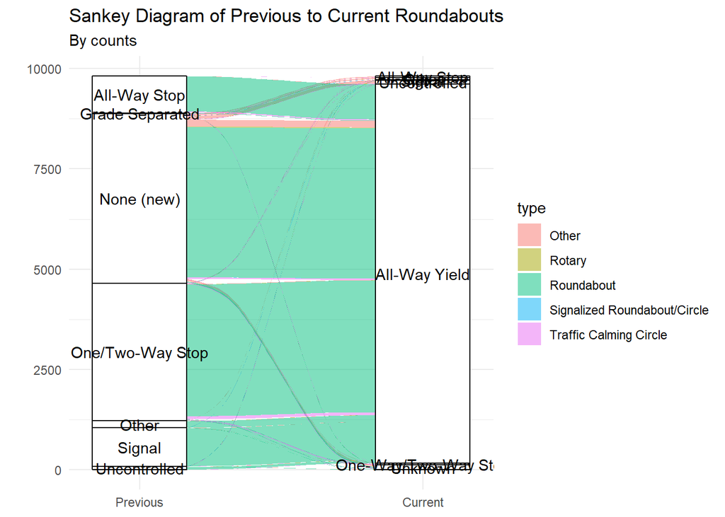

```r
library(ggalluvial)

roundy_sankey |>
ggplot(aes(axis1 = previous_control_type, axis2 = control_type, y = n)) +
  scale_x_discrete(
    limits = c("previous_control_type", "control_type"),
    expand = c(.2, .05),
    labels = c(
      "previous_control_type" = "Previous",
      "control_type" = "Current"
    )
  ) +
  geom_alluvium(aes(fill = type)) +
  geom_stratum() +
  geom_text(stat = "stratum", aes(label = after_stat(stratum))) +
  labs(
    title = "Sankey Diagram of Previous to Current Roundabouts",
    subtitle = "By counts",
    y = ""
  ) +
  theme_minimal()
```

8. Now that you have a working solution, let’s make the strata labels easy to read. Look over this [reference article](https://corybrunson.github.io/ggalluvial/articles/labels.html) on different ways to label the strata for each axis. Implement your favorite method!

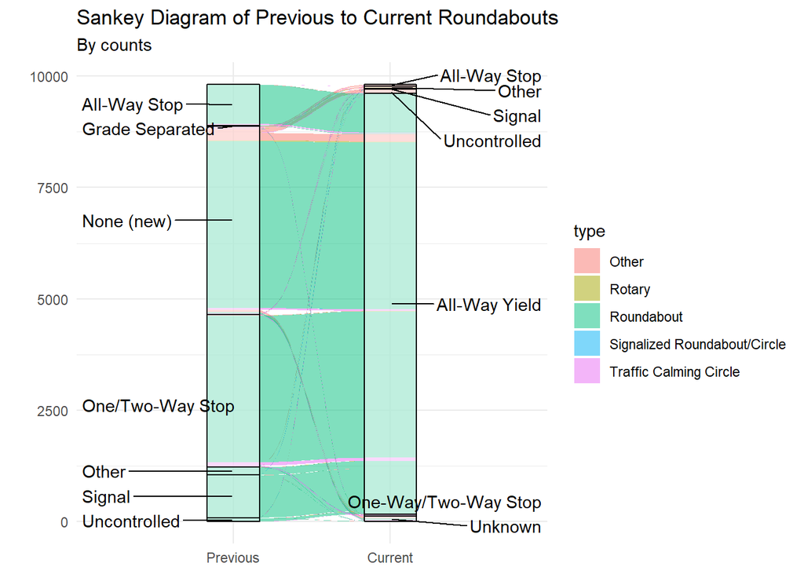

```r
roundy_sankey |>
ggplot(aes(axis1 = previous_control_type, axis2 = control_type, y = n)) +
  scale_x_discrete(
    limits = c("previous_control_type", "control_type"),
    expand = c(.2, .05),
    labels = c(
      "previous_control_type" = "Previous",
      "control_type" = "Current"
      )
    ) +
  geom_alluvium(aes(fill = type)) +
  geom_stratum(alpha = 0.5) +
  ggrepel::geom_text_repel(
    aes(label = ifelse(after_stat(x) == 1, as.character(after_stat(stratum)), NA)),
    stat = "stratum",
    direction = "y",
    nudge_x = -1
  ) +
  ggrepel::geom_text_repel(
    aes(label = ifelse(after_stat(x) == 2, as.character(after_stat(stratum)), NA)),
    stat = "stratum",
    direction = "y",
    nudge_x = 1
  ) +
  labs(
    title = "Sankey Diagram of Previous to Current Roundabouts",
    subtitle = "By counts",
    y = ""
  ) +
  theme_minimal()
```

## Customizing Colors – Required for Both 541 and 431

9. Final touches! Let’s add some custom colors and an informative plot title! *Each of the axes in your plot should have a title as well!*

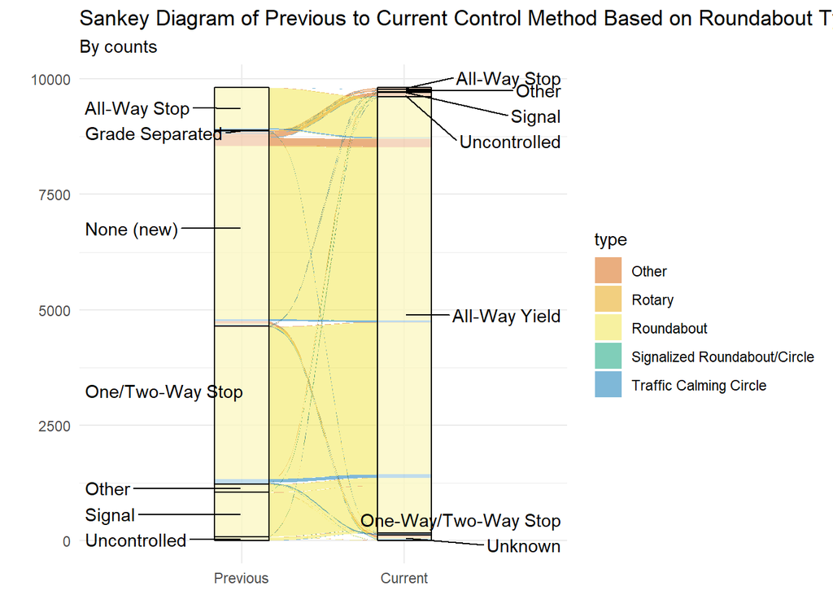

```r
library(ggfittext)

pal <- c("#D55E00", "#E69F00", "#F0E442", "#019E73", "#0072B2")

roundy_sankey |>
  ggplot(aes(axis1 = previous_control_type, axis2 = control_type, y = n)) +
  scale_x_discrete(
    limits = c("previous_control_type", "control_type"),
    expand = c(.2, .05),
    labels = c(
      "previous_control_type" = "Previous",
      "control_type" = "Current"
    )
  ) +
  geom_alluvium(aes(fill = type)) +
  geom_stratum(alpha = 0.5) +
  scale_fill_manual(values = pal) +
  ggrepel::geom_text_repel(
    aes(label = ifelse(after_stat(x) == 1, as.character(after_stat(stratum)), NA)),
    stat = "stratum",
    direction = "y",
    nudge_x = -1
  ) +
  ggrepel::geom_text_repel(
    aes(label = ifelse(after_stat(x) == 2, as.character(after_stat(stratum)), NA)),
    stat = "stratum",
    direction = "y",
    nudge_x = 1
  ) +
  labs(
    title = "Sankey Diagram of Previous to Current Control Method Based on Roundabout Type",
    subtitle = "By counts",
    y = ""
  ) +
  theme_minimal()
```